# Assignment 2: Data 621

Critical Thinking Group 5 - Christina Valore, Henry Vasquez, Chunhui Zhu, Chunmei Zhu, Yuen Chun Wong

```r
library(tidyr); library(dplyr); library(kableExtra); library(pROC); library(caret); library(ggplot2)
```

## 1. Download the classification output data set (attached in Blackboard to the assignment).

```r
data<- read.csv("https://raw.githubusercontent.com/hvasquez81/DATA621/master/classification-output-data.csv")
head(data) %>% kable() %>% kable_styling(bootstrap_options = c("striped", "hover", "condensed"), full_width = TRUE, position = "center", font_size = 15)
```

| pregnant | glucose | diastolic | skinfold | insulin | bmi | pedigree | age | class | scored.class | scored.probability |
| --- | --- | --- | --- | --- | --- | --- | --- | --- | --- | --- |
| 7 | 124 | 70 | 33 | 215 | 25.5 | 0.161 | 37 | 0 | 0 | 0.3284523 |
| 2 | 122 | 76 | 27 | 200 | 35.9 | 0.483 | 26 | 0 | 0 | 0.2731904 |
| 3 | 107 | 62 | 13 | 48 | 22.9 | 0.678 | 23 | 1 | 0 | 0.1096604 |
| 1 | 91 | 64 | 24 | 0 | 29.2 | 0.192 | 21 | 0 | 0 | 0.0559984 |
| 4 | 83 | 86 | 19 | 0 | 29.3 | 0.317 | 34 | 0 | 0 | 0.1004907 |
| 1 | 100 | 74 | 12 | 46 | 19.5 | 0.149 | 28 | 0 | 0 | 0.0551546 |

## 2. The data set has three key columns we will use:

class: the actual class for the observation

scored.class: the predicted class for the observation (based on a threshold of 0.5)

scored.probability: the predicted probability of success for the observation

Q: Use the table() function to get the raw confusion matrix for this scored dataset. Make sure you understand the output. In particular, do the rows represent the actual or predicted class? The columns?

```r
#row: predicted value; columns: actual value
conf_matrix = table(Prediction = data$scored.class, Actual = data$class)
conf_matrix %>% kable() %>% kable_styling(bootstrap_options = c("striped", "hover", "condensed"), full_width = TRUE, position = "center", font_size = 15)
```

|  | 0 | 1 |
| --- | --- | --- |
| 0 | 119 | 30 |
| 1 | 5 | 27 |

## 3. Write a function that takes the data set as a dataframe, with actual and predicted classifications identified, and returns the accuracy of the predictions.

```r
accuracy = function(data, predicted_col_name, actual_col_name) {

  conf = table(data[ , predicted_col_name], data[ , actual_col_name])
  TP = conf[2,2]
  TN = conf[1,1]
  FP = conf[2,1]
  FN = conf[1,2]

  #Accurary = (TP + TN) / (TP + FP +TN +FN)
  return(round((TP+TN)/(TP + FP + TN + FN), 4))
}
print(paste0("Accuracy: ", accuracy(data, 'scored.class', 'class')))
```

```
## [1] "Accuracy: 0.8066"
```

## 4. Write a function that takes the data set as a dataframe, with actual and predicted classifications identified, and returns the classification error rate of the predictions. Verify that you get an accuracy and an error rate that sums to one.

Classification Error Rate = ( FP + FN )/(TP + FP +TN +FN)

```r
errorRate = function(data, predicted_col_name, actual_col_name) {

  conf = table(data[ , predicted_col_name], data[ , actual_col_name])
  TP = conf[2,2]
  TN = conf[1,1]
  FP = conf[2,1]
  FN = conf[1,2]

  #Classification Error Rate = ( FP + FN )/(TP + FP +TN +FN)
  return(round((FP+FN)/(TP + FP + TN + FN), 4))
}

print(paste0("Error rate: ", errorRate(data, 'scored.class', 'class')))
```

```
## [1] "Error rate: 0.1934"
```

```r
#accuracy + error rate
print(paste0("Accuracy + Error rate = ", accuracy(data, 'scored.class', 'class'), " + ", errorRate(data, 'scored.class', 'class'), " = ", (accuracy(data, 'scored.class', 'class') + errorRate(data, 'scored.class', 'class'))))
```

```
## [1] "Accuracy + Error rate = 0.8066 + 0.1934 = 1"
```

## 5. Write a function that takes the data set as a dataframe, with actual and predicted classifications identified, and returns the precision of the predictions.

Precision = TP / (TP + FP)

```r
precision = function(data, predicted_col_name, actual_col_name) {

  conf = table(data[ , predicted_col_name], data[ , actual_col_name])
  TP = conf[2,2]
  TN = conf[1,1]
  FP = conf[2,1]
  FN = conf[1,2]

  #Precision = TP / (TP + FP)
  return(round((TP)/(TP + FP), 4))
}

print(paste0("Precision: ", precision(data, 'scored.class', 'class')))
```

```
## [1] "Precision: 0.8438"
```

## 6. Write a function that takes the data set as a dataframe, with actual and predicted classifications identified, and returns the sensitivity of the predictions. Sensitivity is also known as recall.

Sensitivity = TP / (TP + FN)

```r
sensitivity = function(data, predicted_col_name, actual_col_name) {

  conf = table(data[ , predicted_col_name], data[ , actual_col_name])
  TP = conf[2,2]
  TN = conf[1,1]
  FP = conf[2,1]
  FN = conf[1,2]

  #Sensitivity = TP / (TP + FN)
  return(round((TP)/(TP + FN), 4))
}

print(paste0("Sensitivity: ", sensitivity(data, 'scored.class', 'class')))
```

```
## [1] "Sensitivity: 0.4737"
```

## 7. Write a function that takes the data set as a dataframe, with actual and predicted classifications identified, and returns the specificity of the predictions.

Specificity = TN / (TN+FP)

```r
specificity = function(data, predicted_col_name, actual_col_name) {

  conf = table(data[ , predicted_col_name], data[ , actual_col_name])
  TP = conf[2,2]
  TN = conf[1,1]
  FP = conf[2,1]
  FN = conf[1,2]

  #Specificity = TN / (TN+FP)
  return(round((TN)/(TN + FP), 4))
}

print(paste0("Specificity: ", specificity(data, 'scored.class', 'class')))
```

```
## [1] "Specificity: 0.9597"
```

## 8. Write a function that takes the data set as a dataframe, with actual and predicted classifications identified, and returns the F1 score of the predictions.

F1 Score = 2 * Precision * Sensitivity / (Precision + Sensitivity)

```r
f1_score = function(data, predicted_col_name, actual_col_name) {

  Precision = precision(data, predicted_col_name, actual_col_name)
  Sensitivity = sensitivity(data, predicted_col_name, actual_col_name)

  #F1 Score = 2 * Precision * Sensitivity / (Precision + Sensitivity)
  return(round((2*Precision*Sensitivity)/(Precision + Sensitivity), 4))

}

print(paste0("F1 score: ", f1_score(data, 'scored.class', 'class')))
```

```
## [1] "F1 score: 0.6068"
```

## 9. Before we move on, let’s consider a question that was asked: What are the bounds on the F1 score? Show that the F1 score will always be between 0 and 1. (Hint: If 0 < 𝑎 < 1 and 0 < 𝑏 < 1 then 𝑎𝑏 < 𝑎.)

Using the hint above, we say a = precision and b = sensitivity and both numbers are between 0 and 1. So if a = .5 and b =.5 then a*b = .25 and so a*b < a or a*b < b. To prove that the F1 score is always between 0 and 1, we can run a similation using the idea above, that the p and s values are also between 0 and 1.

By generating random numbers and plugging them into the F1 score equation, we see that as we increase the amount of random numbers from 10 to 100 to 1000, we see that the max value gets close to 1 as the min value gets close 0 but never reaches either value. If we continue to generate more random numbers, we will see the max value continues to rise closer to 1, while the min closer to 0, however the max/min will never be equal to 1/0. Thus the F1 value will always be between 0 and 1

```r
# generate 10 random numbers for precision and recall between 0 and 1
p1 <- runif(10, min = 0, max = 1)
s1 <- runif(10, min = 0, max = 1)
f1 <- 2*p1*s1/(p1+s1)
summary(f1)
```

```
##    Min. 1st Qu.  Median    Mean 3rd Qu.    Max.
## 0.07344 0.09384 0.22048 0.33051 0.61984 0.75236
```

```r
# generate 100 random numbers for precision and recall between 0 and 1
p2 <- runif(100, min = 0, max = 1)
s2 <- runif(100, min = 0, max = 1)
f2 <- 2*p2*s2/(p2+s2)
summary(f2)
```

```
##      Min.   1st Qu.    Median      Mean   3rd Qu.      Max.
## 0.0004549 0.1791056 0.3856525 0.3796340 0.5488254 0.8824900
```

```r
# generate 1000 random numbers for precision and recall between 0 and 1
p3 <- runif(1000, min = 0, max = 1)
s3 <- runif(1000, min = 0, max = 1)
f3 <- 2*p3*s3/(p3+s3)
summary(f3)
```

```
##      Min.   1st Qu.    Median      Mean   3rd Qu.      Max.
## 0.0008883 0.2130912 0.3902332 0.4076334 0.5869547 0.9758995
```

## 10. Write a function that generates an ROC curve from a data set with a true classification column (class in our example) and a probability column (scored.probability in our example). Your function should return a list that includes the plot of the ROC curve and a vector that contains the calculated area under the curve (AUC). Note that I recommend using a sequence of thresholds ranging from 0 to 1 at 0.01 intervals.

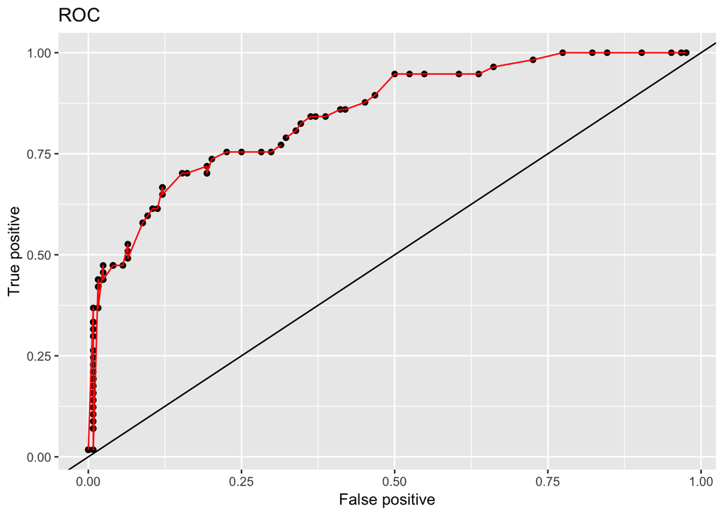

```r
ROC <- function(x){

  seq <- seq(0,1,0.01)
  X_vec <- c()
  Y_vec <- c()

  # calculating each AUC segment
  for (i in 1:length(seq)){
    scored_class <- ifelse(x$scored.probability > seq[i], 1, 0)
    df <- data.frame(scored.class = scored_class, class = x$class)
    df_table <- with(df, table(scored.class, class))
    X <- (df_table[4])/(df_table[4] + df_table[3])
    Y <- (df_table[2]/(df_table[2] + df_table[1]))

    X_vec[i] <- X
    Y_vec[i] <- Y
  }

  XY <- data.frame(True= X_vec, False = Y_vec)

  plot <- ggplot(XY, aes(x=False, y=True))+ geom_point()+ geom_line(col="red") + geom_abline(intercept = 0, slope = 1) + labs(title="ROC", x = "False positive", y = "True positive")

  # remove NA VALUES
  AUC_df <- XY[complete.cases(XY),]

  # Calculate AUC
  x <- abs(diff(AUC_df$False))
  y <- AUC_df$True
  AUC <- sum(x*y)

  return(list(plot, AUC))
}

ROC_list <- ROC(data)
ROC_list[[1]]
```

## 11. Use your created R functions and the provided classification output data set to produce all of the classification metrics discussed above.

```r
print(paste0("Accuracy: ", accuracy(data, 'scored.class', 'class')))
```

```
## [1] "Accuracy: 0.8066"
```

```r
print(paste0("Error rate: ", errorRate(data, 'scored.class', 'class')))
```

```
## [1] "Error rate: 0.1934"
```

```r
print(paste0("Accuracy + Error rate = ", accuracy(data, 'scored.class', 'class'), " + ", errorRate(data, 'scored.class', 'class'), " = ", (accuracy(data, 'scored.class', 'class') + errorRate(data, 'scored.class', 'class'))))
```

```
## [1] "Accuracy + Error rate = 0.8066 + 0.1934 = 1"
```

```r
print(paste0("Precision: ", precision(data, 'scored.class', 'class')))
```

```
## [1] "Precision: 0.8438"
```

```r
print(paste0("Sensitivity: ", sensitivity(data, 'scored.class', 'class')))
```

```
## [1] "Sensitivity: 0.4737"
```

```r
print(paste0("Specificity: ", specificity(data, 'scored.class', 'class')))
```

```
## [1] "Specificity: 0.9597"
```

```r
print(paste0("F1 score: ", f1_score(data, 'scored.class', 'class')))
```

```
## [1] "F1 score: 0.6068"
```

## 12. Investigate the caret package. In particular, consider the functions confusionMatrix, sensitivity, and specificity. Apply the functions to the data set. How do the results compare with your own functions?

```r
confusionMatrix(conf_matrix, positive = '1')
```

```
## Confusion Matrix and Statistics
##
##           Actual
## Prediction   0   1
##          0 119  30
##          1   5  27
##
##                Accuracy : 0.8066
##                  95% CI : (0.7415, 0.8615)
##     No Information Rate : 0.6851
##     P-Value [Acc > NIR] : 0.0001712
##
##                   Kappa : 0.4916
##
##  Mcnemar's Test P-Value : 4.976e-05
##
##             Sensitivity : 0.4737
##             Specificity : 0.9597
##          Pos Pred Value : 0.8438
##          Neg Pred Value : 0.7987
##              Prevalence : 0.3149
##          Detection Rate : 0.1492
##    Detection Prevalence : 0.1768
##       Balanced Accuracy : 0.7167
##
##        'Positive' Class : 1
##
```

```r
caret::sensitivity(conf_matrix, positive = '1')
```

```
## [1] 0.4736842
```

```r
caret::specificity(conf_matrix, negative = '0')
```

```
## [1] 0.9596774
```

Comparing the results to the functions produced previously, all results are the same.

## 13. Investigate the pROC package. Use it to generate an ROC curve for the data set. How do the results compare with your own functions?

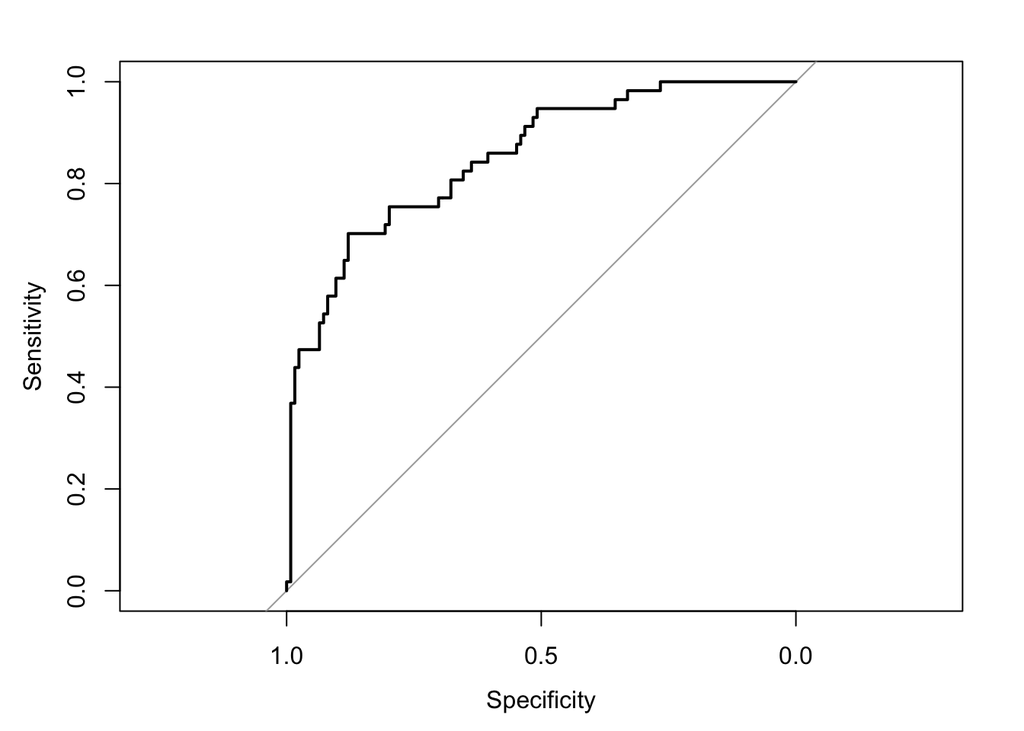

```
##
## Call:
## roc.default(response = data$class, predictor = data$scored.probability,     plot = TRUE)
##
## Data: data$scored.probability in 124 controls (data$class 0) < 57 cases (data$class 1).
## Area under the curve: 0.8503
```

```r
roc(data$class, data$scored.probability, plot = TRUE)
```